# Detect, elect, connect

Week 8 · Chapter 9 · Complex Cognitive Processes

Study · Week 8

Read Chapter 9 first, then this. Week 6 was what the head holds; Week 7 was what it builds. This week is what it can **do** with what it built — think critically, think creatively, and carry an idea from the room it was learned in to a room it was not.

About 13 minutes, including the two places you stop and write — one of them a problem you should genuinely try.

Pair this with **the Walkthrough** — 13 minutes of me deciding what Carlos’s 19/20 was actually measuring, and not being sure it was only one thing.

**This week runs online for both sections** — Tuesday’s session is a page, not a room. Read this first; it is what the page assumes.

## The claim you already believe

**That a student who can do the homework has learned the concept.** Carlos scored 19 of 20. Five days later he could not start a problem that used the same idea in different clothes, and asked *“which type is it?”* Either he forgot in five days — and Week 6 says that is not what forgetting looks like — or the homework was measuring something else.

Start with a problem of your own.

Commit first — actually try this

You are a doctor. A patient has an inoperable tumour in the stomach. A kind of ray can destroy it — but at the intensity needed to destroy the tumour, the ray also destroys the healthy tissue it passes through. At lower intensities the ray is harmless to tissue, and harmless to the tumour.

**How do you destroy the tumour without destroying the healthy tissue?** Write your best attempt, even if it is *“I don’t see it.”*

Hold your answer. Now read this one.

**A general wants to capture a fortress at the centre of a country. Many roads radiate out from it. All are mined: a small group can pass safely, but a large force detonates the mines. A full-scale direct attack is impossible.**

The general divides his army into small groups, sends each down a different road, and has them converge on the fortress at the same moment. It falls.

Most people who read the fortress *after* attempting the tumour see the solution immediately: many weak rays from many directions, converging on the tumour. Most people who read the tumour alone — about nine in ten in Gick and Holyoak’s 1980 study — do not solve it. And most who read the fortress *first*, then the tumour, **still do not solve it** unless they are told the two are related.

That last finding is the whole week. The knowledge was there. It was not *detected* as relevant.

## Transfer: three bridges

Transfer — using what was learned in one context in another The new context can be near or far, and the result can help or hurt. Everything a teacher does is a bet on transfer: nobody teaches percentages so students can do the worksheet.

Perkins and Salomon’s account of what has to happen, and your own framing from the deck:

Detect — notice that something you know is relevant here The fortress readers who failed the tumour did not lack the idea. They did not detect it. Detection runs on **structure**: the problems share a shape and nothing else, and novices see surfaces.

Elect — decide to use it Choosing to reach back rather than say *“we never learned this.”* This is where motivation enters cognition — the value of trying is a cost–benefit judgement, made in a second, usually against.

Connect — work out how it applies Map the old structure onto the new case. Rays are soldiers; the tumour is the fortress; intensity is force. Mapping is effortful, and it is where the learning that lasts happens.

Carlos failed at **detect**. He had the procedure — nineteen of twenty — and did not recognise the jacket problem as an instance of it, because every instance he had practised looked the same. **Twenty problems that share a surface teach students to detect the surface.**

### Kinds of transfer

Positive · negative Prior learning helps, or prior learning gets in the way. Your own examples: *sit / seat, chip / cheap* — Spanish has five vowel sounds, English about fourteen, and the five keep winning. *Embarazada* ≠ embarrassed. A teacher who reads *multiple intelligences* as *learning styles* has transferred a schema that should have stayed home.

Near · far — also *low-road · high-road* **Near / low-road:** similar contexts, automatic, built by practice — homework that matches the worked example; a licensure exam in the same format as the practice quiz. **Far / high-road:** different contexts, deliberate, built by abstraction — using percentages to check a phone bill; using this course to read a real classroom. Near transfer is cheap and is what most practice builds. Far transfer is what most teachers *want*, and it does not come free with near.

**The twenty generated problems built near transfer, perfectly.** Everyone scored well. Compound interest is the same concept with a different surface and a new element, and the class was back where it started. The tool did exactly what it was asked — *twenty similar problems* — and *similar* was the error. A design for transfer would have asked for twenty problems that share the structure and **vary everything else.**

### What builds it

Your deck’s strategy table, compressed — the design menu for the async page:

| Strategy | Builds | Cost |
| --- | --- | --- |
| Practise in **similar** contexts | near transfer, automaticity | none for far |
| **Vary** the practice — surfaces, wrappers, domains | detection of structure | slower, feels harder |
| **Extract the principle** explicitly — *what is the same about these three?* | high-road transfer | needs the learner to do the extracting |
| **Investigate connections** — analogies, *and* where they break | mapping skill | a bad analogy transfers the wrong thing |
| **Teach self-monitoring** — *have I seen this shape before?* | detect, elect | metacognition has to be taught, not assumed |

## Critical thinking: evaluating rather than accepting

Critical thinking — analysis, evaluation, inference Breaking a claim into parts; judging the credibility and relevance of what supports it; drawing the conclusion the evidence actually licenses. The chapter’s three, and your deck’s.

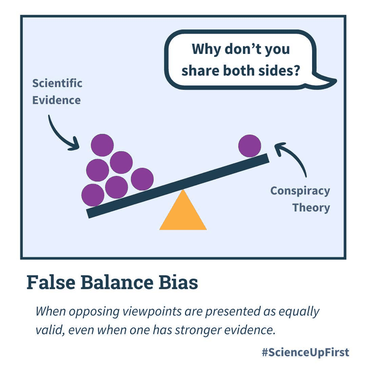

False balance. Image: #ScienceUpFirst.

**Evaluation means weighing what supports each side.** *“Share both sides”* sounds fair, and it skips that step: two positions get equal time whatever they weigh. Part 0 of Tuesday’s page asks you which disagreements evidence can settle.

Argumentation Deductive — from a general rule to a case. Inductive — from cases to a general rule. Abductive — to the best available explanation of incomplete evidence. Most classroom reasoning, and most diagnosis in this course, is abductive.

Mental set · functional fixedness Solving the new problem the way the last one was solved; seeing an object only in its usual role. Ethan: *“up 20%, down 20%, they cancel.”* The set was *percentages are symmetric*, and it was never checked.

Ethan reached the wrong answer in ninety seconds and felt finished. Maddie reached the right one slowly and felt unfinished. **Confidence is a signal about the thinker, not about the answer** — and a tool that returns a confident answer in four seconds inherits the problem.

**Ethan’s move is a default, not a flaw.** The chapter’s dual-process framing: a fast, intuitive system produces the answer that *fits*, and a slower, effortful system checks it — if it is engaged. It usually is not, because the fast answer arrives with a feeling of rightness. Critical thinking is largely the habit of engaging the check when the feeling says you do not need to. Your Friction Move this week (**bat and ball**) tests whether you do, and whether the tool does.

## Creativity: generating, then choosing

Divergent thinking — generating many possibilities Fluency (how many), flexibility (how many kinds), originality (how unusual). Maddie’s three restarts and *“maybe it’s always 96%”* are divergent production under time pressure.

Convergent thinking — choosing the one that works Evaluating the candidates against constraints and committing. Creativity is *both*; a student who generates and cannot converge abandons the task, and a student who converges without generating solves the wrong problem well.

**Maddie did both halves, and the task only had room for one.** She generated: three restarts, a second price, a pattern (*“maybe it’s always 96%”*). She also converged, because the right answer is in there. Nothing told her when to stop generating and commit, so she ended on *“I don’t know if that’s what you wanted”* and ran out of time. A task that wants both has to make room for both, in order, and say which is happening now.

## Novices and experts

The chapter’s account of expertise is the account of why Carlos failed detection. Experts do not have bigger working memories; they have **schemas organised around deep structure**, so a new problem is recognised as a kind of thing. Novices organise around **surface features** — the objects in the problem, the wording — because that is all they can see yet.

This means the novice cannot be told to *look for the structure*. They have to be shown several surfaces with one structure until the structure is what they notice. That is the argument for varied practice, and it is the argument against twenty similar problems.

## What the AI twin looks like

A model’s chain-of-thought is a **worked example** — steps, in order, that look like reasoning. Sometimes it is. Sometimes it is a pattern that matches the surface of the problem and produces the answer that usually follows that surface, which is precisely Ethan. The bat-and-ball problem is a classic test because the intuitive answer is so strongly associated with the wording that both people and models produce it unless something makes them check.

For your own tool, this is Milestone 2 in two lines: **what must transfer** (Part 2), and **the measure that would show it did** — a new case, not another problem from the same mould (Part 5).

## Check yourself

Check yourself

A student learned to write a persuasive essay in class, then writes one on a new topic for homework. Which kind of transfer?

Too far Same genre, same structure, same setting, new topic. The contexts are similar; the application is close to automatic.

Yes Similar context, practised skill, a small change of surface. This is what most homework builds, and it is worth building — it is just not the same as far transfer, which would be using the persuasive structure in a science report or a job application.

Nothing is getting in the way Negative transfer is prior learning that hurts. Here it helps.

It is transfer The topic changed. That is a new context, however near. Transfer is a matter of distance, not a yes/no.

Check yourself

A Spanish speaker learning English reads *embarazada* in a Spanish text and, thinking in English now, assumes it means *embarrassed*. This is:

The direction is wrong Something was transferred, but it hurt. Positive transfer helps.

Wrong on both counts The contexts are close (two languages, one word-shape) and the result is an error.

Yes Detection fired on the surface — the letters — and connected to the wrong structure. This is what detection does before a learner has enough varied cases to notice which similarities matter. It means *pregnant*.

Different concept Functional fixedness is seeing an object only in its usual role. This is a mapping error between two knowledge bases.

Bring to Tuesday’s page **Your answer to case question 1** — what the homework was measuring, in the chapter’s words.

**Your tumour attempt** from above — you will compare it to the tool’s on the page.

**One concept from your subject that students can do on the homework and not in the wild.** You will write the item that tells the difference.

Retrieval check closes **Tuesday at noon**, as always. The page opens with whatever the room missed — you will see the item statistics on it.

*This week feeds Milestone 2, Part 2 (reason, critique, create, transfer) and Part 5 (a new case as the measure).*

## Sources

Kahneman, D. (2011). *Thinking, fast and slow.* Farrar, Straus and Giroux.

Frederick, S. (2005). Cognitive reflection and decision making. *Journal of Economic Perspectives, 19*(4), 25–42.

Stanovich, K. E., & West, R. F. (1997). Reasoning independently of prior belief and individual differences in actively open-minded thinking. *Journal of Educational Psychology, 89*(2), 342–357.

Baron, J. (1985). *Rationality and intelligence.* Cambridge University Press.